# HW 3: Exploring bivariate relationships in the 2019 Canada Election Study

POG230

Stefanie Baxter

2022-11-11

# Instructions

You will be required to complete this homework assignment in RStudio as an R Markdown (.rmd) file. When it is completed, please upload the assignment to the corresponding folder in D2L in TWO formats: an .rmd file and a “knitted” file that is either in .pdf, .html, or .doc format. Your TA will review how to do these things with you in lab.

For each sub-question, please write your answer using numbers and prose using text following each prompt and show your work (i.e., your code) in the R chunk provided below each prompt. If the prompt does not require new code (you can obtain the answer from the code you typed for the previous question), you may write `#see above` in the R chunk for that prompt. Your TA will review how to do this with you in lab.

# Some Tips

- Recall that there is more than one way to compute the same thing in R (just like there is more than one way to communicate the same thing in any language). You may use the textbook, labs, and Q&A sessions with your TA to work through each problem.
- For some problems, you will be asked to correct existing code. For these problems, correct the code provided in the R chunk and state in prose what you did to fix the code.
- You are advised to START EARLY on each homework. Do not be discouraged by getting stuck. Learning R and statistics requires trial, error, and support. However, you will not have time to work through the assignment successfully if you start it the night before the due date.

# About the 2019 Canada Election Study

The Canada Election Study 2019 (CES 2019) was a national-level online survey conducted by a team of Canadian political scientists during the 2019 campaign (September 13-October 21, 2019) and post-election season (October 24 - November 11, 2019). Some of the questions on the survey asked about electoral attitudes and behaviours, including what party respondents planned to vote for and how the respondents felt about different parties and their leaders. The survey also asks for some sociodemographic characteristics of the respondents, including their age, gender, and level of education.

In this homework, you will be asked to examine the relationships between some of these variables. Because the nationwide sample is very large, we will filter to a less populated province - Manitoba - to examine these relationships.

# Question 1

1. Obtain a summary of the data and comment on the number of variables and observations in the data set.

```r
ces_cps_2019 %>%
  summary()
```

```
##  cps19_province     cps19_votechoice   cps19_fed_donate   cps19_news_cons
##  Length:36033       Length:36033       Length:36033       Length:36033
##  Class :character   Class :character   Class :character   Class :character
##  Mode  :character   Mode  :character   Mode  :character   Mode  :character
##
##
##
##
##  cps19_vote_2015    cps19_gender       cps19_spend_educ   cps19_prov_gov_sat
##  Length:36033       Length:36033       Length:36033       Length:36033
##  Class :character   Class :character   Class :character   Class :character
##  Mode  :character   Mode  :character   Mode  :character   Mode  :character
##
##
##
##
##  cps19_prov_id        cps19_age     cps19_Q_TotalDuration cps19_party_rating_24
##  Length:36033       Min.   :18.00   Min.   : 500          Min.   :  0.00
##  Class :character   1st Qu.:35.00   1st Qu.: 904          1st Qu.: 10.00
##  Mode  :character   Median :49.00   Median :1169          Median : 41.00
##                     Mean   :48.73   Mean   :1297          Mean   : 43.64
##                     3rd Qu.:62.00   3rd Qu.:1547          3rd Qu.: 74.00
##                     Max.   :99.00   Max.   :3599          Max.   :100.00
##                                                           NA's   :2659
##  cps19_income_number cps19_union        cps19_bornin_canada
##  Min.   :      0     Length:36033       Length:36033
##  1st Qu.:  43000     Class :character   Class :character
##  Median :  72000     Mode  :character   Mode  :character
##  Mean   :  84673
##  3rd Qu.: 110000
##  Max.   :1000000
##  NA's   :11736
##  cps19_party_rating_23 cps19_party_rating_25 cps19_lead_rating_23
##  Min.   :  0.00        Min.   :  0.00        Min.   :  0.00
##  1st Qu.: 16.00        1st Qu.: 27.00        1st Qu.:  7.00
##  Median : 55.00        Median : 54.00        Median : 50.00
##  Mean   : 48.37        Mean   : 49.99        Mean   : 44.84
##  3rd Qu.: 77.00        3rd Qu.: 73.00        3rd Qu.: 75.00
##  Max.   :100.00        Max.   :100.00        Max.   :100.00
##  NA's   :2503          NA's   :3658          NA's   :2287
##  cps19_groups_therm_1 cps19_groups_therm_2 cps19_groups_therm_3
##  Min.   :  0.00       Min.   :  0.00       Min.   :  0.0
##  1st Qu.: 50.00       1st Qu.: 44.00       1st Qu.: 41.0
##  Median : 67.00       Median : 63.00       Median : 62.0
##  Mean   : 63.18       Mean   : 60.15       Mean   : 60.4
##  3rd Qu.: 83.00       3rd Qu.: 81.00       3rd Qu.: 84.0
##  Max.   :100.00       Max.   :100.00       Max.   :100.0
##  NA's   :6445         NA's   :5969         NA's   :6584
##  cps19_groups_therm_4 cps19_groups_therm_5 cps19_turnout_2015
##  Min.   :  0.00       Min.   :  0.00       Length:36033
##  1st Qu.: 37.00       1st Qu.: 24.00       Class :character
##  Median : 60.00       Median : 40.00       Mode  :character
##  Mean   : 56.73       Mean   : 41.24
##  3rd Qu.: 80.00       3rd Qu.: 60.00
##  Max.   :100.00       Max.   :100.00
##  NA's   :5914         NA's   :5568
```

2. To prepare the data for analysis, please use the `mutate` function to turn `cps19_province` and `cps19_votechoice` into factor variables. Run a summary of the data set again to ensure that these variables have been transformed from character (string) variables into factor variables.

```r
ces_cps_2019 <- ces_cps_2019 %>%
  mutate(cps19_province=factor(cps19_province), # convert to factor
         cps19_votechoice=factor(cps19_votechoice))

class(ces_cps_2019$cps19_votechoice) # verify variable type
```

```
## [1] "factor"
```

```r
class(ces_cps_2019$cps19_province)
```

```
## [1] "factor"
```

```r
summary(ces_cps_2019)
```

```
##           cps19_province                          cps19_votechoice
##  Ontario         :14160   Liberal Party                   :8557
##  Quebec          : 7919   Conservative Party              :8323
##  Alberta         : 4256   Don't know/ Prefer not to answer:4651
##  British Columbia: 4172   NDP                             :4133
##  Manitoba        : 1618   Green Party                     :2320
##  Saskatchewan    : 1271   (Other)                         :2097
##  (Other)         : 2637   NA's                            :5952
##  cps19_fed_donate   cps19_news_cons    cps19_vote_2015    cps19_gender
##  Length:36033       Length:36033       Length:36033       Length:36033
##  Class :character   Class :character   Class :character   Class :character
##  Mode  :character   Mode  :character   Mode  :character   Mode  :character
##
##
##
##
##  cps19_spend_educ   cps19_prov_gov_sat cps19_prov_id        cps19_age
##  Length:36033       Length:36033       Length:36033       Min.   :18.00
##  Class :character   Class :character   Class :character   1st Qu.:35.00
##  Mode  :character   Mode  :character   Mode  :character   Median :49.00
##                                                           Mean   :48.73
##                                                           3rd Qu.:62.00
##                                                           Max.   :99.00
##
##  cps19_Q_TotalDuration cps19_party_rating_24 cps19_income_number
##  Min.   : 500          Min.   :  0.00        Min.   :      0
##  1st Qu.: 904          1st Qu.: 10.00        1st Qu.:  43000
##  Median :1169          Median : 41.00        Median :  72000
##  Mean   :1297          Mean   : 43.64        Mean   :  84673
##  3rd Qu.:1547          3rd Qu.: 74.00        3rd Qu.: 110000
##  Max.   :3599          Max.   :100.00        Max.   :1000000
##                        NA's   :2659          NA's   :11736
##  cps19_union        cps19_bornin_canada cps19_party_rating_23
##  Length:36033       Length:36033        Min.   :  0.00
##  Class :character   Class :character    1st Qu.: 16.00
##  Mode  :character   Mode  :character    Median : 55.00
##                                         Mean   : 48.37
##                                         3rd Qu.: 77.00
##                                         Max.   :100.00
##                                         NA's   :2503
```

[output cut: 9 more lines]

```
##  Min.   :  0.00       Min.   :  0.0        Min.   :  0.00
##  1st Qu.: 44.00       1st Qu.: 41.0        1st Qu.: 37.00
##  Median : 63.00       Median : 62.0        Median : 60.00
##  Mean   : 60.15       Mean   : 60.4        Mean   : 56.73
##  3rd Qu.: 81.00       3rd Qu.: 84.0        3rd Qu.: 80.00
##  Max.   :100.00       Max.   :100.0        Max.   :100.00
##  NA's   :5969         NA's   :6584         NA's   :5914
##  cps19_groups_therm_5 cps19_turnout_2015
##  Min.   :  0.00       Length:36033
##  1st Qu.: 24.00       Class :character
##  Median : 40.00       Mode  :character
##  Mean   : 41.24
##  3rd Qu.: 60.00
##  Max.   :100.00
##  NA's   :5568
```

3. Similarly, use the `mutate` function to give the variable `cps19_party_rating_25` a new name: `cps19_rating_NDP`. You may wish to run a summary again to check your work.

```r
ces_cps_2019 <- ces_cps_2019 %>%
  rename(cps19_rating_NDP=cps19_party_rating_25) # rename(newname = oldname)
```

4. The code behind the hash-tags below uses the `mutate` function once again to add a new factor variable to the data set called `cps19_partyvote` that re-organizes `cps19_votechoice` by grouping respondents who voted for parties other than the Conservative Party, the Liberal Party, and the NDP into one group called “other”. However, there is a typo in the code! Please find the typo and correct it so that the code functions properly (you’ll want to delete the hash-tags at the beginning of each line of code so you can actually run the code). Run a summary of your data again to ensure that your new variable is there.

```r
ces_cps_2019 <- ces_cps_2019 %>% # added pipe
 mutate(cps19_partyvote = factor(if_else(cps19_votechoice=="Conservative Party", "Conservative",
                               if_else(cps19_votechoice == "Liberal Party", "Liberal",
                                       if_else(cps19_votechoice == "NDP", "NDP",
                                                "others")))))

ces_cps_2019 %>%
  summary()
```

```
##           cps19_province                          cps19_votechoice
##  Ontario         :14160   Liberal Party                   :8557
##  Quebec          : 7919   Conservative Party              :8323
##  Alberta         : 4256   Don't know/ Prefer not to answer:4651
##  British Columbia: 4172   NDP                             :4133
##  Manitoba        : 1618   Green Party                     :2320
##  Saskatchewan    : 1271   (Other)                         :2097
##  (Other)         : 2637   NA's                            :5952
##  cps19_fed_donate   cps19_news_cons    cps19_vote_2015    cps19_gender
##  Length:36033       Length:36033       Length:36033       Length:36033
##  Class :character   Class :character   Class :character   Class :character
##  Mode  :character   Mode  :character   Mode  :character   Mode  :character
##
##
##
##
##  cps19_spend_educ   cps19_prov_gov_sat cps19_prov_id        cps19_age
##  Length:36033       Length:36033       Length:36033       Min.   :18.00
##  Class :character   Class :character   Class :character   1st Qu.:35.00
##  Mode  :character   Mode  :character   Mode  :character   Median :49.00
##                                                           Mean   :48.73
##                                                           3rd Qu.:62.00
##                                                           Max.   :99.00
##
##  cps19_Q_TotalDuration cps19_party_rating_24 cps19_income_number
##  Min.   : 500          Min.   :  0.00        Min.   :      0
##  1st Qu.: 904          1st Qu.: 10.00        1st Qu.:  43000
##  Median :1169          Median : 41.00        Median :  72000
##  Mean   :1297          Mean   : 43.64        Mean   :  84673
##  3rd Qu.:1547          3rd Qu.: 74.00        3rd Qu.: 110000
##  Max.   :3599          Max.   :100.00        Max.   :1000000
##                        NA's   :2659          NA's   :11736
##  cps19_union        cps19_bornin_canada cps19_party_rating_23 cps19_rating_NDP
##  Length:36033       Length:36033        Min.   :  0.00        Min.   :  0.00
##  Class :character   Class :character    1st Qu.: 16.00        1st Qu.: 27.00
##  Mode  :character   Mode  :character    Median : 55.00        Median : 54.00
##                                         Mean   : 48.37        Mean   : 49.99
##                                         3rd Qu.: 77.00        3rd Qu.: 73.00
##                                         Max.   :100.00        Max.   :100.00
##                                         NA's   :2503          NA's   :3658
```

[output cut: 9 more lines]

```
##  Min.   :  0.0        Min.   :  0.00       Min.   :  0.00
##  1st Qu.: 41.0        1st Qu.: 37.00       1st Qu.: 24.00
##  Median : 62.0        Median : 60.00       Median : 40.00
##  Mean   : 60.4        Mean   : 56.73       Mean   : 41.24
##  3rd Qu.: 84.0        3rd Qu.: 80.00       3rd Qu.: 60.00
##  Max.   :100.0        Max.   :100.00       Max.   :100.00
##  NA's   :6584         NA's   :5914         NA's   :5568
##  cps19_turnout_2015     cps19_partyvote
##  Length:36033       Conservative:8323
##  Class :character   Liberal     :8557
##  Mode  :character   NDP         :4133
##                     others      :9068
##                     NA's        :5952
##
##
```

5. Create a new `tibble` that filter this updated data set to only include respondents from Manitoba. Name the new data set `manitoba`. (Hint: when you filter by province, the value you choose for your desired province is called “Manitoba”). How many observations are there in this new data set? How many variables?

```r
manitoba <- ces_cps_2019 %>%
  filter(cps19_province=="Manitoba")
```

This new data set has 25 variables (which makes sense as it should be the same as our original data), and 1618 observations. We know this is correct because if we compare with our above summary when we changed cps19_province to a factor variable, we can see that Manitoba had a count of 1618.

# Question 2

1. Using the `manitoba` data set, you will now examine the bivariate relationship between the party respondents voted for in the 2019 election (`cps19_partyvote`) and respondents’ approval of the NDP (`cps19_rating_NDP`). What kind of variable is `cps19_partyvote`? What kind of variable is `cps19_rating_NDP`? (HINT: You can use the terms “factor” and “numeric” here.)

cps19_partyvote is a factor variable since it was created using the data from cps19_votechoice, which we previously converted to a factor variable, and it’s made up of different categories (parties - making it categorical). cps19_rating_NDP is a numeric variable because it can take on a multitude of numeric values.

2. Examine the relationship between these two variables visually using a box plot. Label your x-axis “Party voted for in 2019”, your y-axes “NDP rating”, and the plot title, “Approval of NDP by party vote in 2019”.

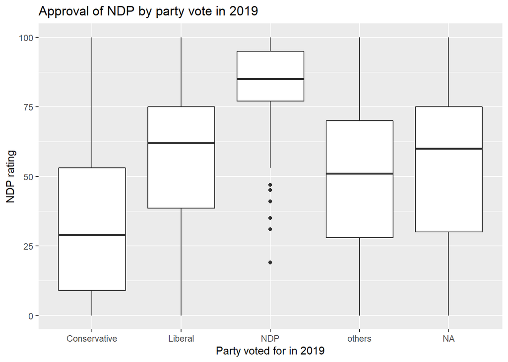

```r
ggplot(manitoba, aes(y=cps19_rating_NDP, x=cps19_partyvote)) +
  geom_boxplot() +
  labs(y="NDP rating", x="Party voted for in 2019", title="Approval of NDP by party vote in 2019")
```

3. Comment on the results of the boxplot, in terms of central tendency and dispersion, particularly with respect to the 3 main parties.

It’s no surprise that NDP voters gave the highest ratings to the NDP. The median for NDP voters ratings is above the median of all the other parties boxes, meaning that the median (‘middle’) rating given by NDP voters in higher than the rating given by all other parties. This box is also the smallest, meaning that there is less variability in the ratings given. Thus, NDP voters generally rate the NDP highly, and the ratings don’t deviate much from the median. Liberals rate the NDP higher than do the Conservatives, in general, which we can see by comparing their medians and position of their boxes with respect to the y axis. However, both the Liberals and Conservatives have large interquartile ranges. This indicates that within each of these groups, there is a lot of variability regarding how voters feel towards the NDP, thus more dispersion from the mean (or median in this case), on average.

4. Try to obtain a correlation between these two variables. You will notice the code doesn’t work. Why doesn’t it work? (Before you knit your file, put the code for this behind a hash tag in your r chunk so it will knit properly.)

```r
# cor(cps19_partyvote, cps19_rating_NDP)
```

This does not work since cps19_partyvote is a factor variable. Correlation depends on variables being numeric, since their numeric values are what need to be taken into account when calculating correlation.

# Question 3

1. Using the `manitoba` data set, obtain a scatterplot between respondents’ age and rating of the NDP. Label your x-axis “Respondent age”, your y-axes “NDP rating”, and the plot title “NDP approval by respondent age”. (Hint: in your `aes()` function, be sure that age is your x variable and NDP rating is your y variable!)

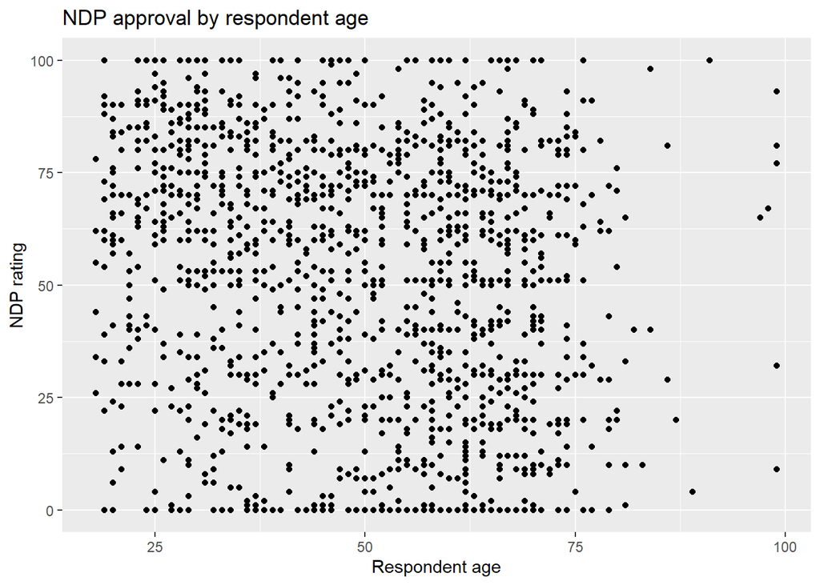

```r
manitoba %>%
  ggplot(aes(x=cps19_age, y=cps19_rating_NDP)) +
  geom_point() +
  labs(x="Respondent age", y="NDP rating", title="NDP approval by respondent age")
```

2. Comment on the results of your scatter plot. What kind of relationship (if any) do these variables appear to have, just by glancing at this plot?

From the scatterplot, it’s very hard to tell if they have a relationship at all. If they do, it’s hard to tell whether or not this relationship is positively or negatively correlated. My guess would be that they have a weak negative correlation since there is an ever so slightly higher concentration of dots on the negative 45 degree slope.

3. Obtain the correlation between these two variables. HINT: because the correlation command will not work if you have missing values, you need to type the following at the end of the correlation code: `use = "complete.obs"`). Use a comma to separate this from your second variable in the code.

```r
correlation=cor(manitoba$cps19_rating_NDP, manitoba$cps19_age,use = "complete.obs")
correlation
```

```
## [1] -0.1945348
```

4. What does your correlation suggest about the relationship between age and NDP approval? How does this compare with your initial assessment stated previously? What DOESN’T this correlation tell you about the relationship between these two variables?

The correlation is negative indicating that as respondent age increases, their NDP rating decreases. Comparing it with my previous assessment/guess, I was more or less correct. The correlation is very small in magnitude, meaning that the relationship between these two variables is weak. It does not tell us if one variable causes the other, or give any indication to what the relating factor (or factors) between the two variables is.

5. Run an OLS regression (i.e., a linear model) where age predicts NDP approval (remember to specify that `data = manitoba` at the end of the command). Store this model in an object called `fit`. Which variable is the independent variable, and which is the dependent variable? Why wouldn’t it make sense to have the two variables reversed?

```r
fit=lm(cps19_rating_NDP ~ cps19_age, data=manitoba)
```

The independent variable is respondent age, and the dependent variable is their approval rating of the NDP. Reversing the two would not allow us to observe any linear relationship since a person’s feelings toward the NDP cannot affect their age.

6. use the `tidy()` command to obtain a neat regression table with the results of this linear model. Interpret the substantive meaning of the intercept AND the slope. (HINT: look at lab 6 for an example of how to do this if you need a reminder!)

```r
tidy(fit)
```

```
## # A tibble: 2 × 5
##   term        estimate std.error statistic   p.value
##   <chr>          <dbl>     <dbl>     <dbl>     <dbl>
## 1 (Intercept)   67.9      2.42       28.1  7.01e-139
## 2 cps19_age     -0.351    0.0465     -7.55 7.85e- 14
```

The intercept is 67.89, meaning that when the age is is 0, the NDP rating is is 67.89. The slope of -0.35 indicates that when age increases by one unit, NDP rating decreases by 0.35 units on average.

7. Given your regression coefficient estimates from the table above, what is the predicted value of NDP approval for a 50 year old? How about for a 25 year old? (HINT: This requires some very simple math, and you are welcome to use r to do it for you! You can round to the nearest hundredth in your calculations.)

```r
# regression line is y = alpha + beta*x
alpha=67.89
beta=-0.35
x=c(50,25)
Y=alpha+beta*x
Y # outputs a vector with Y(50) and Y(25), respectively
```

```
## [1] 50.39 59.14
```

The above calculations indicate that at age 50, the predicted NDP rating is 50.39, and that the predicted rating at age 25 is 59.14.